# Rabivy AI Engine

A question-answering system over prescriber records and a clinical/competitive knowledge base

Author

Tilabo Williamson, Caitlin Buenk & Jürgen Becker (Project Lead) - AX Consult Group

Published

2026-07-24

[figure not shown]

Project Overview Evaluation Suite Live Queries and User Feedback Dashboard Write Up Maintenance Dashboard

# Introduction

*AX Consult Group - commercial showcase.*

The goal was to build an engine that could serve Rabivy (a hypothetical GLP-1 drug) reps by giving them a searchable, answerable knowledge base - something that could take the two separate piles of information a rep actually needs (the hard prescriber data, and the clinical/competitive knowledge reps are expected to know) and let them just ask it questions, instead of digging through a spreadsheet or trying to remember the right talking point.

Practically, that means it can answer things like:

- *“who’s the top prescriber in Texas”* or
- *“which High-tier endocrinologists in Florida haven’t been targeted yet”*

Which makes up the hard-numbers side of a rep’s job. It can also answer narrative questions that make up the talking points side like:

- *“why should a doctor choose Rabivy over Zepbound”* or
- *“what do I say to someone who’s happy with their current treatment”*

And because most real questions are actually both at once, it can combine them:

- *“who should I see next month, and what’s my pitch”*

Which pulls a real name from the data and real language from the knowledge base, in one answer.

What follows is a layer-by-layer walkthrough of how it actually works, with the matching piece of the architecture shown alongside each step. Below is a graphic showing the full pipeline of how this engine works from top to bottom, layer-by-layer.

[figure not shown]

Graphic breakdown of the full AI engine pipeline

# The two raw sources

These two different kinds of questions are answered by two different kinds of data.

### Spreadsheet data

Raw prescriber data, simulated to reflect real-world sources like Komodo and IQVIA, merged by National Provider Identifier (NPI). This houses everything about prescribing volume, HCP information, and the rest of the structured record for each doctor.

This spreadsheet houses variables such as:

#### About the doctor

*- basic identity and practice background*

- NPI (National Provider Identifier)
- Specialty
- Years in practice
- State

#### GLP-1 related

*- how this doctor prescribes GLP-1s today*

- Whether the doctor is an active prescriber
- Monthly prescription volume
- Monthly new prescriptions
- Formulary tier
- Prior authorization burden
- Percent of prescriptions that are Novo Nordisk
- Percent of prescriptions that are Lilly
- Percent of prescriptions that are other brands

#### About their patients

*- who this doctor’s patient population looks like*

- Percent of patients on commercial insurance
- Percent of patients on Medicare
- Percent of patients on Medicaid
- Percent of patients paying out-of-pocket
- Obesity prevalence in patient population

#### About rep/company engagement

*- the history between this doctor and the company*

- Relationship status with the rep
- Whether the doctor is currently targeted
- Days since last contact
- Whether a sample was requested recently

#### Generated scores

*- modeled scores predicting prescribing and switching likelihood*

- Propensity score
- Propensity tier (High / Medium / Low)
- Switching score

The **propensity score** is a weighted sum of several variables, run through a sigmoid so the result lands between 0 and 100%. Each variable gets a fixed weight - a positive weight pushes the score up, a negative weight pulls it down.

| Variable | What it means | Weight |
| --- | --- | --- |
| Rx volume | How many GLP-1 prescriptions the doctor writes each month | +0.3 |
| New-patient share | How much of that volume is new patients, not refills | +2.0 |
| Prior authorization burden | How much insurance friction this doctor’s patients face | -2.5 |
| Rep engagement | How engaged the doctor has been with the rep | +0.8 |
| Formulary status | Whether Rabivy is preferred, non-preferred, restricted, or not covered for this doctor’s patients | 0 to -1.8, depending on status |
| Existing relationship | Whether the doctor already prescribes another company product | 0 to +0.6, depending on how many |

The **switching score** works the same way, using a smaller version of the same formula (rep engagement and existing relationship only).

| Variable | What it means | Weight |
| --- | --- | --- |
| Rep engagement | How engaged the doctor has been with the rep | +1.2 |
| Existing relationship | Whether the doctor already prescribes another company product | 0 to +1.5, depending on how many |

Every weight is fixed ahead of time - the formulae don’t change from doctor to doctor or recalculate. The same weights are applied identically to every prescriber in the data. However, these formulae should be checked and updated regularly as actual prescribing data comes in. Once the drug is live it might be sensible to have dynamic scores that change based on what actually predicts propensity to prescribe or to switch.

### Narrative documents

These are documents such as rep talking points, Rabivy’s key benefits, competitor rundowns, and medical coverage summaries.

These documents include:

#### Clinical & scientific reference

*- the science behind Rabivy and the class it competes in*

- Overview of the GLP-1 drug class (how it works, approved uses, major clinical trials)
- Rabivy’s clinical summary (mechanism, Phase 2 results, development status)
- Real-world evidence on patient persistence and why people stop taking GLP-1s

#### Real published literature

*- genuine, unsimplified journal articles, ingested through the same pipeline as every other document, used to test retrieval and synthesis against real literature rather than content written to be easy to retrieve*

- Cooper, M.E. & van Raalte, D.H. (2025), *GLP-1 agonists in the treatment of chronic kidney disease in type 2 diabetes and obesity* (Journal of Clinical Investigation) - a review of the clinical trial evidence (including the FLOW and SELECT trials) and the proposed biological mechanisms behind GLP-1 receptor agonists’ kidney-protective effects.
- Meier et al. (2026), *Glucagon-Like Peptide-1 Receptor Agonists in Chronic Kidney Disease* - a review of renoprotective mechanisms, including receptor expression and signaling pathways implicated in slowing kidney disease progression.
- Chen et al. (2025), *Kidney and Cardiovascular Outcomes Among Patients With CKD Receiving GLP-1 Receptor Agonists* (American Journal of Kidney Diseases) - a systematic review and meta-analysis of kidney and cardiovascular outcomes specifically in patients with reduced baseline kidney function.

These three are what the Evaluation Suite page’s article-retrieval and article-agent tracks are tested against.

#### Market & competitive reference

*- the competitive and access landscape Rabivy is entering*

- Competitive intelligence brief (the other GLP-1 drugs and companies, and where Rabivy stands against them)
- Payer and market access brief (insurance coverage, prior authorization, and access barriers by payer type)
- State-by-state market summary

#### Benchmarks & reference data

*- typical prescriber patterns, to judge any one doctor against*

- Specialty benchmark profiles (typical prescribing patterns for primary care, endocrinology, and obesity medicine)

#### Rep-facing sales enablement

*- what a rep says and reaches for in the field*

- Rabivy’s product and benefits brief (what to say about the drug itself)
- Objection handling guide (how to respond to common pushback from doctors)
- Talking points by doctor segment (how to tailor the pitch to different kinds of prescribers)

#### Doctor account snapshots

*- a one-page profile for each doctor in the data*

- One snapshot per doctor, combining their prescribing history, patient mix, insurance access situation, competitive landscape, and relationship with the company into a single reference page

# Layer 1 - Chunk, Tag, Embed

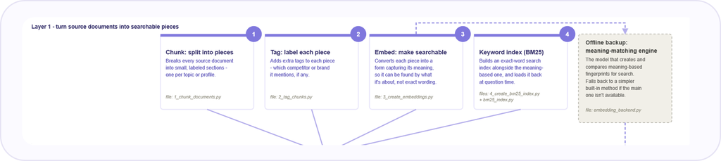

Layer 1

`raw document` → **chunk** (`1_chunk_documents.py`) → **tag** (`2_tag_chunks.py`) → **embed** (`3_create_embeddings.py`) + **keyword-index** (`4_create_bm25_index.py`) → `searchable output`

- **Chunking** (`1_chunk_documents.py`) - splits each document into small, labeled sections rather than treating a whole brief as one block. One HCP snapshot becomes one chunk; a longer brief becomes several, one per section.
- **Tagging** (`2_tag_chunks.py`) - adds structured metadata to each chunk: which competitor or brand it mentions, which document type it came from, which state or specialty it’s tied to if relevant. This is what later lets a search be filtered, not just ranked.
- **Embedding** (`3_create_embeddings.py`) - converts each tagged chunk into a numeric vector that captures its meaning rather than its exact wording, using a sentence-embedding model. That’s what lets a question like *why pick Rabivy over Zepbound* find the right passage even if it doesn’t use those exact words - the match happens in vector space, not on keywords.
- **Keyword indexing** (`4_create_bm25_index.py`) - builds a second, separate index from the same tagged chunks, using a classic keyword-match algorithm (BM25) instead of meaning. It scores a chunk by how many of the question’s literal words it actually contains - the same basic idea search engines have used for decades. Only narrative chunks are indexed (HCP cards are excluded, since those are always looked up by exact NPI/state/specialty, never free-text searched). This is what catches the case the embedding step above can miss: a chunk that uses the *exact right words* but that the embedding model’s sense of “meaning” happens to rank low anyway - see Layer 4 for how the two get combined.

Two supporting modules wrap the actual model/algorithm logic so the driver scripts above stay simple: `embedding_backend.py` wraps whichever embedding model is actually available - normally a proper sentence-transformer, with a lighter-weight fallback if that model can’t be loaded (for example, in a CI environment with no internet access) - and `bm25_index.py` wraps the BM25 build/query logic itself. Both are called identically at build time and at query time, so what gets searched always matches what got indexed.

This process creates a searchable vector store *and* a searchable keyword index that together form the second half of the knowledge base, alongside the spreadsheet.

**Real articles get one extra step first.** Every document described earlier (rep talking points, competitor briefs, benchmark profiles) was written to already be clean, well-structured text - but the three real published journal articles (see “Real published literature” above) aren’t. A raw academic PDF is genuinely messy to pull text out of: two-column layouts, running headers and footers repeated on every page, citation markers stuck directly onto the words around them, and section structure that a naive PDF-to-text extraction throws away entirely. Feeding that straight into the chunking step above would produce chunks that are broken or misleading in ways a rep skimming an answer would never notice.

Real articles are cleaned and parsed *before* they ever reach `1_chunk_documents.py`, using **GROBID** - an open-source machine-learning model trained specifically to read the layout of a scientific PDF. GROBID reads a PDF and hands back its real structure - correctly ordered sections, headings, and paragraphs, instead of a flat wall of text - which then gets converted into the same kind of markdown `1_chunk_documents.py` already expects from every other document. An authoritative citation lookup (via Crossref, using the DOI GROBID pulls from the paper’s own header) fills in the title, authors, and journal afterward, so every chunk can be traced back to “Author et al. (Year),” not just a generic section label.

All three of the real articles used to test this system went through this cleaning step before entering the same chunk → tag → embed → keyword-index pipeline as everything else on this page.

# Layer 2 - Build Pipeline

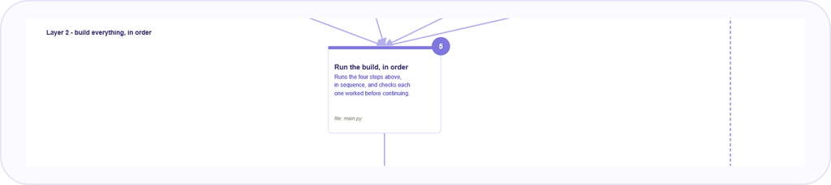

Layer 2

**Build everything, in order.** The four steps above have to run in sequence - tagging needs chunks to exist, embedding needs tags to exist - and each one has to actually succeed before the next starts. `main.py` is that orchestration layer:

- runs chunking → tagging → embedding → keyword index, in order
- checks the output of each stage before moving to the next, rather than assuming success
- fails loudly and stops if a stage produces something malformed, instead of quietly passing bad data downstream

This needs to be re-run any time the source documents or the underlying spreadsheet change - it’s a build step, not something that runs per-question.

# Layer 3 - The Two Sources

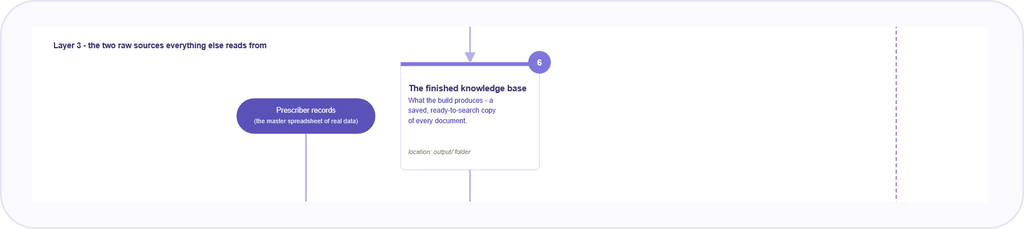

Layer 3

**The two raw sources everything else reads from.** Once `main.py` finishes, there are exactly two places real information lives, and every later layer reads from one or the other:

- **The `output/` folder** - the finished vector store from Layer 1: tagged chunks plus their embeddings, saved to disk so nothing needs to be rebuilt at question time.
- **The prescriber spreadsheet** - a separate `.xlsx` file of prescriber-level records, merged by National Provider Identifier (NPI), that never passes through the chunk/tag/embed pipeline at all since it’s already structured.

Nothing downstream reaches past these two sources for a fact - if it isn’t in one of these, the system doesn’t know it.

# Layer 4 - The Two Engines

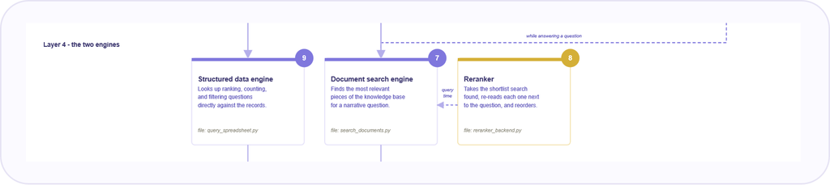

Layer 4

**The two engines.** Two engines sit directly on top of the two raw sources, and each one only ever touches its own source:

- **`Spreadsheet Query Engine → query_spreadsheet.py`** - the structured engine. Runs ranking, counting, and filtering directly against the prescriber records: top-N by propensity score, active-writer counts by state, filtered lists by tier/specialty/formulary status. No language interpretation happens here - it takes clean parameters (a state name, a tier, a metric) and returns rows.
- **`Document Search Engine → search_documents.py`** - the retrieval engine, and where the two indexes built in Layer 1 actually get used together. A query goes through three steps:
  1. **Two independent rankings** - the query is embedded and compared against every chunk’s embedding (meaning match, from Layer 1’s vector store), *and* scored against the BM25 keyword index (literal word match, from Layer 1’s keyword index) - two separate ranked lists of the same chunks, from two different signals.
  2. **Fusion** - the two rankings are combined into one using Reciprocal Rank Fusion (RRF - Cormack, Clarke & Buettcher, 2009), a standard method that rewards a chunk for ranking well on *either* signal, so a chunk doesn’t need to win on both to surface.
  3. **Reranking** - the top 20 fused candidates are re-read by a small cross-encoder model (`cross-encoder/ms-marco-MiniLM-L-6-v2`; Nogueira & Cho, “Passage Re-ranking with BERT”, 2019) that scores the query and each candidate chunk *together*, one pair at a time, rather than comparing them separately the way steps 1-2 do. Reading the two together tends to catch relevance the separate signals miss, but it’s too slow to run over the whole library - which is why it only ever sees this final shortlist of 20, not the full chunk set.

  The result is filtered by the tags from Layer 1 (competitor, state, document type) throughout.

Concretely, there’s no model inside `query_spreadsheet.py`. `query_spreadsheet.py` holds the prescriber table in memory and contains lookup functions such as `top_prescriber()`, `count_writers()`, and `top_n_by_propensity()` - plain filters and sorts, not language understanding. `search_documents.py` is different since the reranker step above: it holds the embedding matrix and BM25 index from Layer 1 in memory for the first two steps, then calls the small cross-encoder model for the third. `reranker_backend.py` wraps that model the same way `embedding_backend.py` wraps the embedding model - if it can’t be loaded, the system logs it plainly and falls back to the RRF-fused order from step 2 instead of failing silently.

Neither engine *interprets* a question at all - no routing decision, no extracted filters, nothing about intent - that happens one layer down, in Layer 5. The reranker judges chunk relevance, not question intent.

# Layer 5 - Two Question Paths

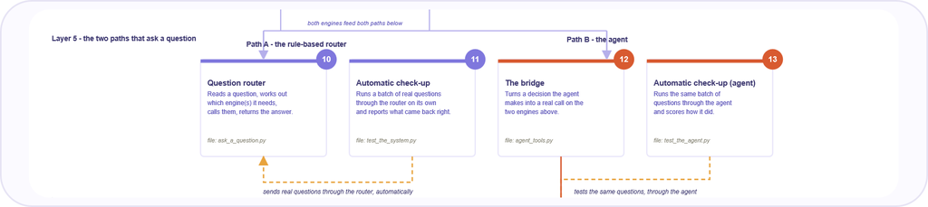

Layer 5

**The two paths that ask a question.** A question can travel one of two routes, and this is where the “understand what’s being asked” work actually happens:

**Path A - the rule-based router (`ask_a_question.py`)**

- Pattern-matches an incoming question against a set of known question shapes (top-N, count, filter, lookup)
- Extracts parameters directly from the text (state names, tiers, NPIs) using regex and lookup tables, not a model
- Calls the matching engine from Layer 4 directly and returns its output
- Deterministic and fast, but only as good as the patterns it’s been given - it doesn’t generalize to phrasing it hasn’t seen (its major shortcoming)
- Verified by `test_the_system.py`, which runs a fixed batch of real questions through it and reports which came back correct

**Path B - the agent (`agent_tools.py`)**

- Reads the question and, via an LLM call through Layer 6, decides which tool to call and with what arguments, instead of matching a fixed set of regex patterns
- The agent in layer 6 calls out to `agent_tools.py`, which acts purely as the bridge - it exposes Layer 4’s two engines as callable tools and translates the model’s tool-call output into an actual function call, nothing more
- Generalizes better to novel phrasing than Path A, at the cost of an LLM call and its associated latency/cost
- Verified by `test_the_agent.py`, run against the same question set as Path A’s test, so the two paths can be compared apples-to-apples on accuracy, not just architecture

Both paths ultimately call the same two engines from Layer 4 - the difference is entirely in how the question gets translated into a call.

## Why Path A still exists

Path A wasn’t a deliberate safety design - it’s what came first. Early on, before the agent (Path B) existed, the regex router was the fastest way to prove the retrieval and spreadsheet engines underneath actually worked at all: a rough, keyword-matching test harness for those two engines, not a production architecture choice. Once Path B was built out, it became the real path - the one that actually generalizes to phrasing the regex patterns were never written to catch.

Path A is kept today mostly as a legacy comparison point: free to run, deterministic, and useful as a baseline the agent’s own accuracy can be checked against apples-to-apples (see test_the_system.py on the Evaluation Suite page). It isn’t protecting a number from the agent, either - Path B pulls its numbers from the exact same deterministic spreadsheet engine (Layer 4) that Path A does, so a number reaching a rep never passes through language generation under either path.

# Layer 6 - Agent’s Brain

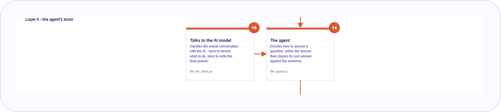

Layer 6

**The agent’s brain.** When Path B is used, two files do the actual thinking:

- **`llm_client.py`** - the thin wrapper around the model API itself. `agent.py` calls into it twice per question: once with the tool definitions from `agent_tools.py` to decide which tool to call and with what arguments, and again afterward to turn the raw tool output into a written answer.
- **`agent.py`** - the orchestrator. It sequences the two `llm_client.py` calls, passes the retrieved evidence (from either engine in Layer 4) into the answer-writing step, and then runs a third pass that checks the drafted answer against that same evidence before anything is returned upstream.

That third pass is deliberately a separate model call from the one that wrote the answer - not a self-review by the same generation - which is what Layer 7’s trust note below is really about.

# Layer 7 - The Chat UI

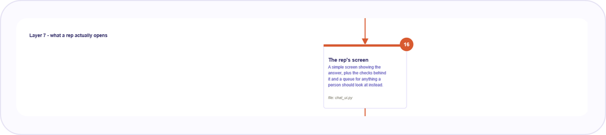

Layer 7

**What a rep actually opens.** `chat_ui.py` is the last stop - a lightweight interface that renders the final answer alongside four automatic checks, run the moment the answer is produced, so nothing is a black box:

1. **Tool grounding** - was a real tool actually called, rather than the model answering from nothing?
2. **Retrieval confidence** - did the retrieved chunks match the question closely enough (cosine similarity above a threshold), with no tool errors?
3. **Source citations** - did the written answer actually cite something it retrieved?
4. **Hallucination audit** - the pass/fail result of the Layer 6 verification check, visible rather than hidden.

It’s a thin presentation layer on top of everything above it - no logic of its own beyond formatting and displaying these checks. See the figure below for an illustration of the user interface.

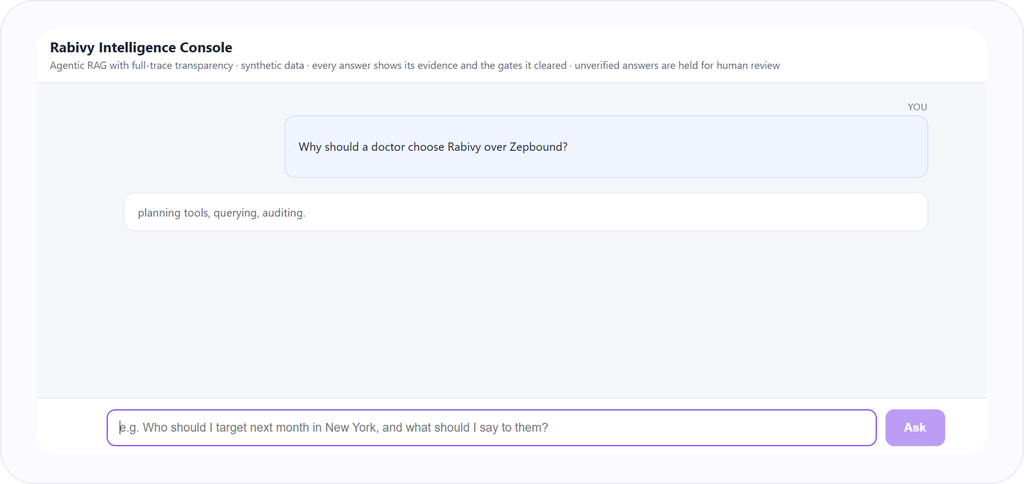

Chat User Interface

## What a rep can actually ask it

A few real examples, across both kinds of questions from earlier:

- *“Who’s the top prescriber in Texas?”* - structured, answered directly from the spreadsheet
- *“Which High-tier endocrinologists in Florida haven’t been targeted yet?”* - structured with multiple filters
- *“Why should a doctor choose Rabivy over Zepbound?”* - narrative, pulled from the competitive knowledge base
- *“What do I say to someone who’s happy with their current treatment?”* - narrative, pulled from the objection-handling guide
- *“Who should I see next month, and what’s my pitch?”* - both at once: a real name from the spreadsheet, real language from the knowledge base, combined in one answer

See the image below for an example of a simple lookup question:

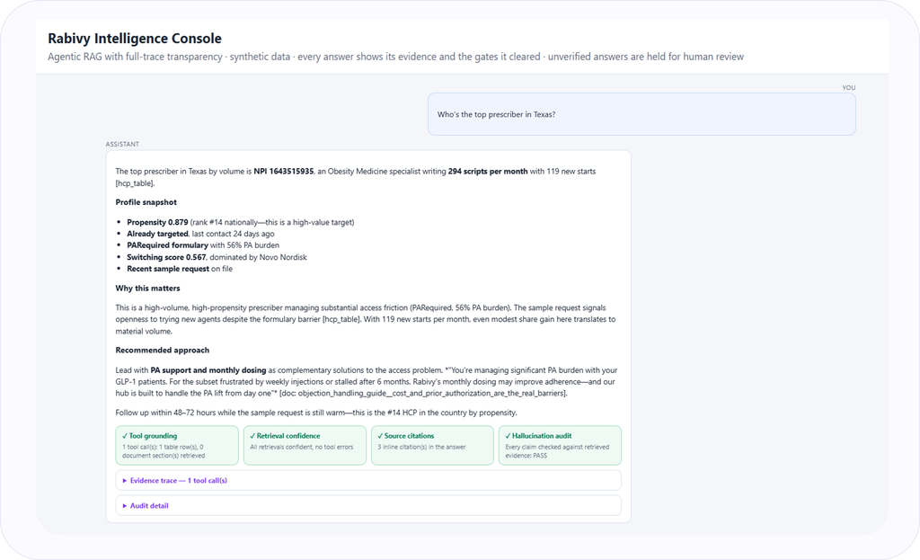

Example of a simple lookup question

The image below shows a more complex question:

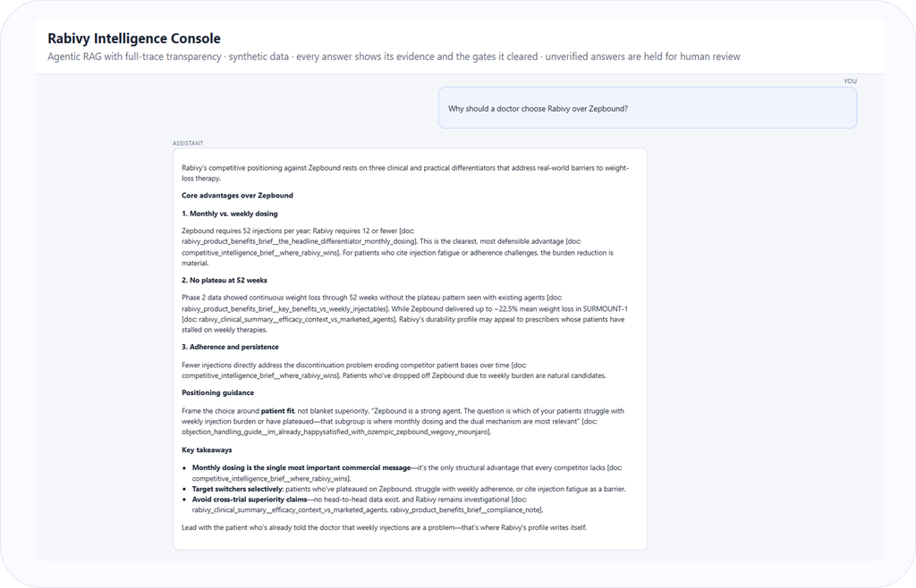

Example of a more complex question

**A note on trust:** nothing in Layer 6 is allowed to answer from what the model already assumes - only from what was actually retrieved in Layers 3 and 4. If the evidence doesn’t contain an answer, the system says so plainly rather than guessing.

Before an answer ever reaches Layer 7, a separate model call - not the one that wrote the answer - checks every factual claim in it against the retrieved evidence, and flags anything unsupported or contradicted. If that audit fails, the system gets one automatic chance to rewrite the answer using only what’s in the evidence, then re-checks it. If it still fails - or the audit itself errors out - the answer is held back from the rep entirely: shown as pending human review, with the auditor’s specific objections attached, instead of the answer itself.

# Layer 8 - Live Queries and User Feedback

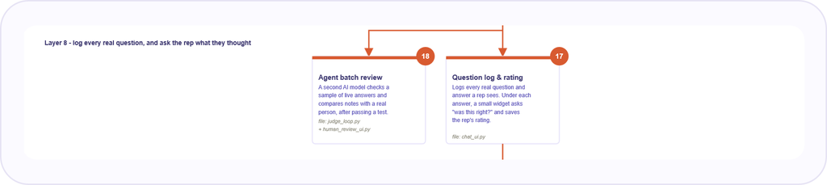

Layer 8

**What happens to a question after it’s answered.** Every real question a rep asks through `chat_ui.py` is logged automatically, and every answer is checked against four automatic gates - no human involved. A rep can also leave a rating on any answer they look at, correct or not, which is what the user feedback system captures. A random sample is also batch reviewed by a second, independent agent as a stress test of the hallucination audit gate.

- **Automatic gates** - every live answer is checked for tool grounding, retrieval confidence, source citations, and a hallucination audit, the moment it’s produced.
- **User feedback review** - optional, rep-initiated. A short set of prompts turns a rep’s judgement into one of eight fixed outcomes, from a clean correct answer down to a hallucination.
- **Batch review** - a secondary agent batch reviews a random sample of green and amber queries after passing an entrance exam to stress test the audit gate

The full breakdown the four gates, the user feedback prompt flow, and the decision trees behind each, plus the Agent Batch Review that runs a second, independent AI check calibrated against a human rater - is covered on the Live Queries and User Feedback page.

# Layer 9 - Maintenance Dashboard

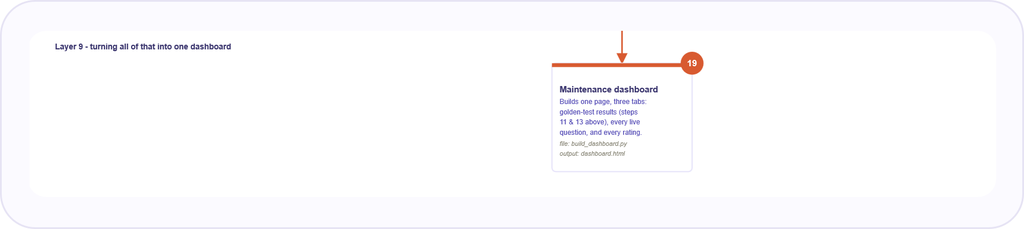

Layer 9

**Where all of the above actually gets looked at.** `build_dashboard.py` reads the golden-test results from Layer 5, the live query log, and the user feedback ratings from Layer 8, and turns them into one static page (`dashboard.html`) with three tabs - Golden Test Set, Live Queries, and User Feedback.

It isn’t wired into an automatic pipeline yet - someone has to run `python build_dashboard.py` and push the result whenever it needs refreshing.

A tab-by-tab breakdown, the decision tree behind each tab, and what it actually takes to keep it current is covered on the Maintenance Dashboard page.

# Standalone - Support Modules

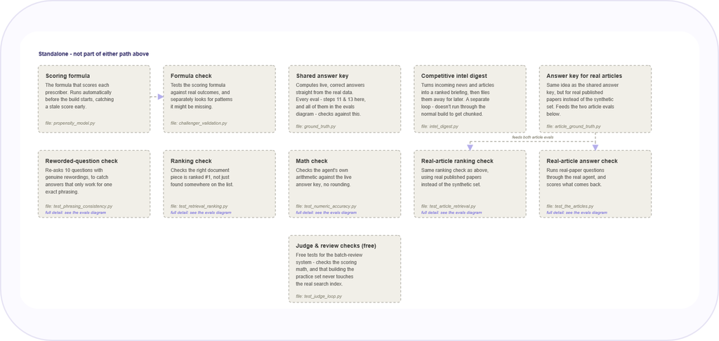

Standalone

**What sits outside the main flow.** A few pieces support the system without sitting on either question-answering path above:

- **`propensity_model.py`** - the literature-informed scoring formula that produces each prescriber’s propensity and switching scores in the spreadsheet. It’s run once, ahead of time, as part of data preparation - never recalculated live by a model at query time.
- **`challenger_validation.py`** - reads `propensity_model.py`’s scores and checks them against simulated real-world outcomes (did the doctors it predicted would switch actually switch), and separately looks for patterns the hand-built formula might be underweighting.
- **`intel_digest.py`** - a separate loop entirely: turns a batch of incoming external signals (conference abstracts, publications, regulatory readouts, payer/market news) into a ranked, email-ready briefing, then feeds the processed items into the same knowledge base the chat assistant reads from. See the Competitive intelligence digest section below for the full walkthrough.
- **The evaluation suite** - seven further files (`ground_truth.py`, `test_phrasing_consistency.py`, `test_retrieval_ranking.py`, `test_numeric_accuracy.py`, plus the real-literature track: `article_ground_truth.py`, `test_article_retrieval.py`, `test_the_articles.py`) that test specific properties the golden 30 alone can’t verify. All outlined in detail, including what each one found, on the Evaluation Suite page.
- **`judge_loop.py`** - the second, independent “contrarian” judge behind Layer 8’s batch review: a separate model that re-checks a random sample of live answers against their evidence, blind, to catch cases where Layer 6’s own hallucination audit might be wrong about itself. It’s only trusted on real traffic after passing a calibration step first - an “entrance exam” of known-answer cases, scored before it ever sees a real query. **`test_judge_loop.py`** is its test suite - free, no API key or model call needed, since it checks the judge’s own scoring logic, the entrance exam’s pass-bar math, and the agreement math against a human rater (Cohen’s kappa) in isolation, plus a direct check that building the exam never mutates the real index files. See Live Queries and User Feedback for how the batch review itself is used.

# Why the answer can actually be trusted

The uncomfortable fact about language models is that asking one to write an answer isn’t the same as trusting it to only say true things. Left alone, a model can produce something confident and well-written that’s simply wrong - a misremembered name, an invented number, a claim that sounds right but isn’t. For a system reps make real decisions from, that’s a significant risk for a project like this.

The system prompt driving Layer 6’s answer-writing step gives the model one explicit constraint: only use what was actually retrieved in Layers 3 and 4, never whatever it already assumes about GLP-1 drugs or prescribing patterns in general. That’s an instruction, not a guarantee - which is exactly why the separate audit pass described in the Note on Trust above exists: a second model call, independent of the one that wrote the answer, checks every claim against the evidence and can send it back for one automatic rewrite, or hold it for human review if it still doesn’t hold up.

What a rep actually sees are the four gates from Layer 7, shown alongside every answer:

1. **Tool grounding** - was a real tool actually called?
2. **Retrieval confidence** - did the retrieved chunks match closely enough?
3. **Source citations** - did the answer cite what it retrieved?
4. **Hallucination audit** - did the independent audit above come back clean?

See the figure below for these checks shown on the user interface.

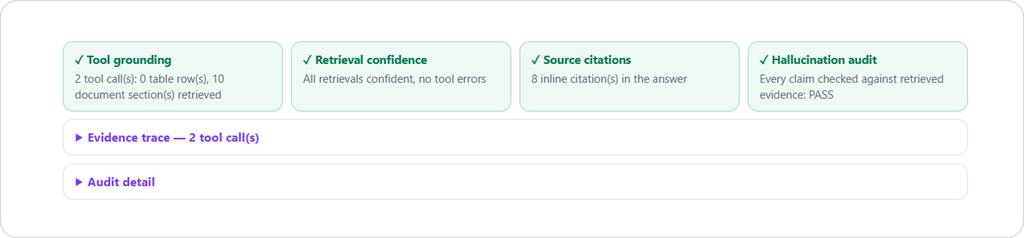

User interface checks

And when there genuinely isn’t an answer - a doctor with no name given, a place that isn’t a real state, a question the data has no answer to - the system says so plainly. An honest “I don’t know” rather than a confident guess. That’s not a limitation. It’s what makes the rest of it trustworthy.

The figure below shows how the engine replies when an invalid question is asked (e.g., an NPI that doesn’t exist in the database).

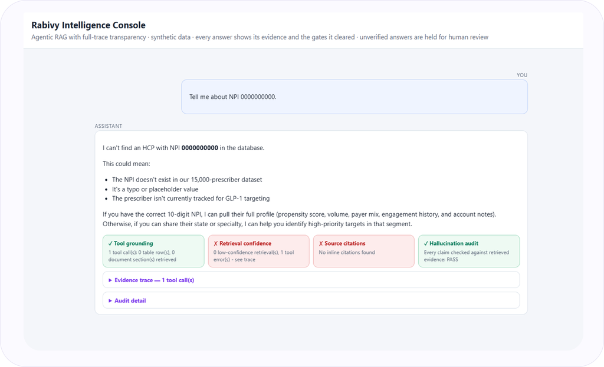

Example of the engine rejecting a question without an answer in the database

# Competitive intelligence digest

Everything covered so far answers questions against a fixed snapshot of data. But a pharma competitive landscape doesn’t hold still - new trial readouts, FDA filings, and payer decisions show up constantly, and a knowledge base that only reflects last quarter’s picture becomes misleading fast.

Scoring uses the LLM directly against Rabivy’s actual strategic positioning (monthly dosing, durability, tolerability vs. Novo/Lilly) - not a fixed rulebook - so the rationale for each item’s ranking is specific to what that item actually says, not a generic template. An offline keyword-based fallback exists for when no API key is available, consistent with the rest of the system’s approach to graceful degradation. See the image below for the ranked threat/opportunity output.

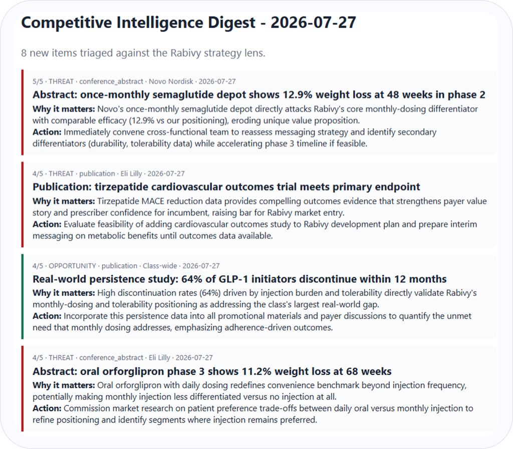

Competitive intelligence digest: news pieces ranked by threat/opportunity, each with model-generated rationale tied to Rabivy’s actual strategic position

*All content shown here is synthetic/simulated, consistent with the rest of this showcase.*

# Where this goes from here

This is a working showcase, not a finished product.

For a full walkthrough of how this system is tested including the real bugs that were found and fixed - see the Evaluation Suite page.

*AX Consult Group. Rabivy is used here as a commercial analytics showcase and is not intended for clinical use.*

[View the project on GitHub](https://github.com/AX-Consult-Group/medical-Rabivy-AI-engine)

Project Overview Evaluation Suite Live Queries and User Feedback Dashboard Write Up Maintenance Dashboard